# DANL 310 Lecture 07

February 17, 2022

## Graph tables, add labels, make notes

## Graph tables, add labels, make notes

- We will learn about how to transform data *before* we send it to ggplot to be turned into a figure.
- We will expand the number of geoms we know about, and learn more about how to choose between them.
  - How to reorder the variables displayed in our figures;
  - How to subset the data we use before we display it.
- We will learn a little more about the scale, guide, and theme functions.

## Loading the R packages

```r
library(tidyverse)
```

```r
library(skimr)   # a better summary of data frame
library(scales)  # scales for ggplot
library(gapminder) # gapminder data
library(socviz)  # data for visualization practice
library(ggrepel)  # for text on plot, geom_text_repel(), geom_label_repel()
```

## The 2016 General Social Survey data

- The `socviz` package includes the `gss_sm` data frame.
  - `gss_sm` is a dataset containing an extract from the 2016 General Social Survey.

```r
?gss_sm
glimpse(gss_sm)
skim(gss_sm)
view(gss_sm)
```

## Graph tables

```r
p <- ggplot(data = gss_sm,
            mapping = aes(x = bigregion, fill = religion))
p + geom_bar(position = "fill")
```

- Setting the position argument to `"fill"` in the `geom_bar()` is to compare proportions across groups.

## Graph tables

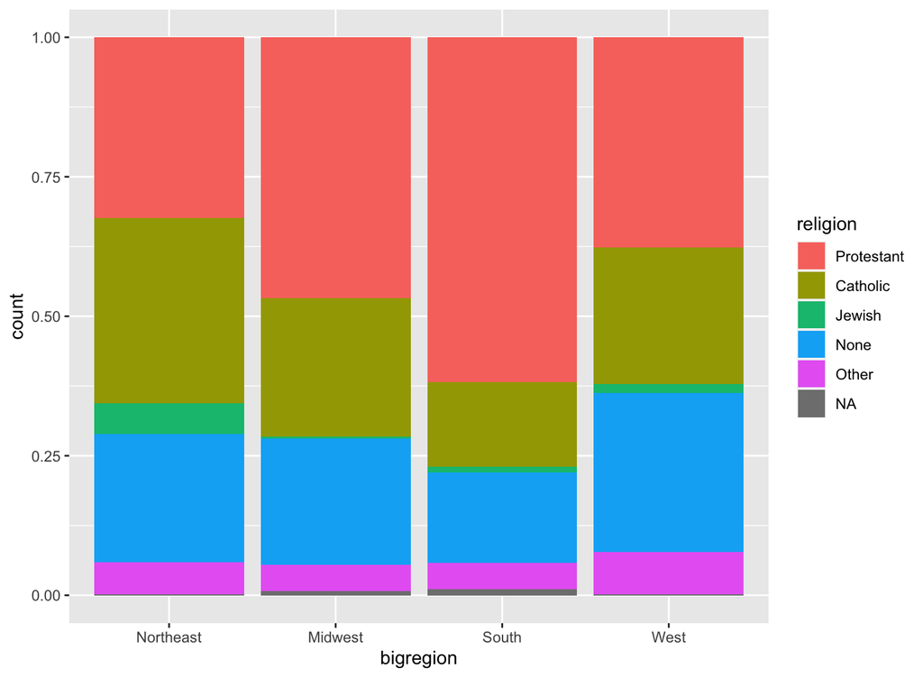

## Graph tables

[figure not shown]

## Graph tables

```r
p <- ggplot(data = gss_sm,
            mapping = aes(x = bigregion ))
p + geom_bar(position = "dodge",
             mapping = aes(y = ..prop.., group = religion)) +
    facet_wrap(~ religion, ncol = 1)
```

- Instead, we can ask ggplot to give us a proportional bar chart of region, and then facet that by religion.
  - The proportions are calculated within each panel, which is the breakdown we wanted.

## Graph tables

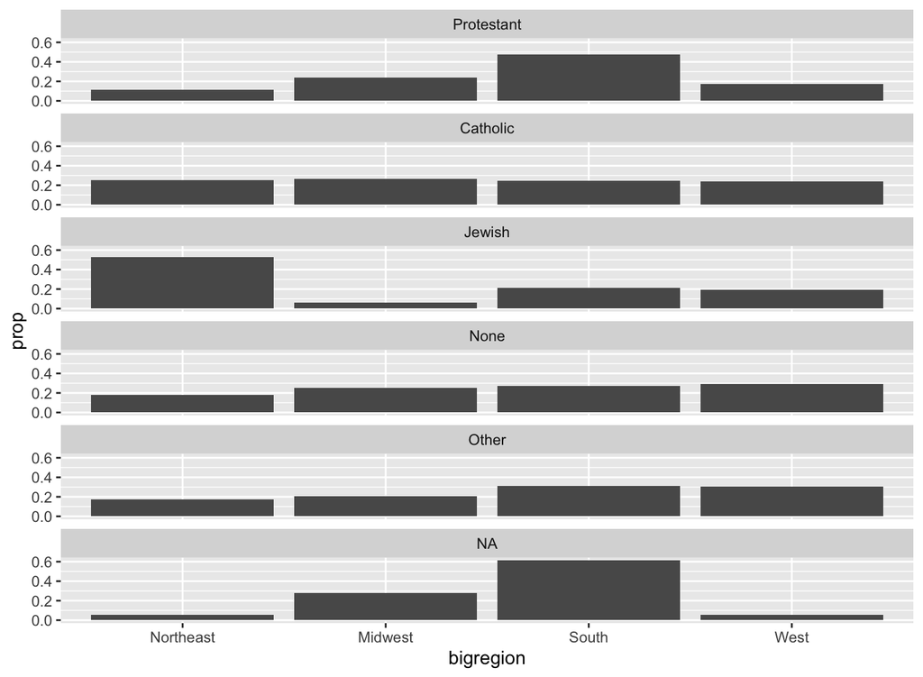

## Graph tables

[figure not shown]

## Graph tables

[figure not shown]

## Use pipes to summarize data

- We will use the `%>%` (pipe) operator when tidying data.
  - The point of the pipe is to help you write code in a way that is easier to read and understand.
  - A good way to pronounce `%>%` when reading code is “then”.

## Use pipes to summarize data

- A pipeline is typically a series of operations that do one or more of four things:
  - `group_by()`: Group the data into the nested structure we want for our summary, such as “Religion by Region” or “Authors by Publications by Year”.
  - `filter()` rows or `select()` columns: Filter or select pieces of the data by row, column, or both.
  - `mutate()`: Mutate the data by creating new variables at the current level of grouping.
  - `summarize()`: Summarize or aggregate the grouped data.
    - For example we might calculate means with `mean()` or counts with `n()`.

## Use pipes to summarize data

```r
rel_by_region <- gss_sm %>%
    group_by( bigregion, religion ) %>%
    summarize( N = n() ) %>%
    mutate( freq = N / sum(N),
            pct = round((freq*100), 0) )
rel_by_region
```

```
## # A tibble: 24 × 5
## # Groups:   bigregion [4]
##    bigregion religion       N    freq   pct
##    <fct>     <fct>      <int>   <dbl> <dbl>
##  1 Northeast Protestant   158 0.324      32
##  2 Northeast Catholic     162 0.332      33
##  3 Northeast Jewish        27 0.0553      6
##  4 Northeast None         112 0.230      23
##  5 Northeast Other         28 0.0574      6
##  6 Northeast <NA>           1 0.00205     0
##  7 Midwest   Protestant   325 0.468      47
##  8 Midwest   Catholic     172 0.247      25
##  9 Midwest   Jewish         3 0.00432     0
## 10 Midwest   None         157 0.226      23
## # … with 14 more rows
```

## Use pipes to summarize data

- Reading from the left, the code says this:
  - `rel_by_region <- gss_sm %>%`: Create a new object, `rel_by_region`. Start with the gss_sm data, and then …
  - `group_by(bigregion, religion) %>%`: Group the rows by bigregion and, within that, by religion.

## Use pipes to summarize data

- `summarize(N = n()) %>%`: Summarize this table to create a new, much smaller table, with three columns:
  - `bigregion`
  - `religion`
  - `N`: a count of the number of observations within each religious group for each region.

## Use pipes to summarize data

- `mutate(freq = N / sum(N), pct = round((freq*100), 0))`: With this new table, use the `N` variable to calculate two new columns:
  - the relative proportion (`freq`)
  - the percentage (`pct`) for each religious category, still grouped by region.
    - Round the results to the nearest percentage point.

## Use pipes to summarize data

```r
rel_by_region %>% group_by(bigregion) %>%
    summarize(total = sum(pct))
```

```
## # A tibble: 4 × 2
##   bigregion total
##   <fct>     <dbl>
## 1 Northeast   100
## 2 Midwest     101
## 3 South       100
## 4 West        101
```

## Use pipes to summarize data

```r
p <- ggplot(rel_by_region, aes(x = bigregion, y = pct, fill = religion))

p + geom_col(position = "dodge") +
    labs(x = "Region",y = "Percent", fill = "Religion") +
    theme(legend.position = "top")
```

## Use pipes to summarize data

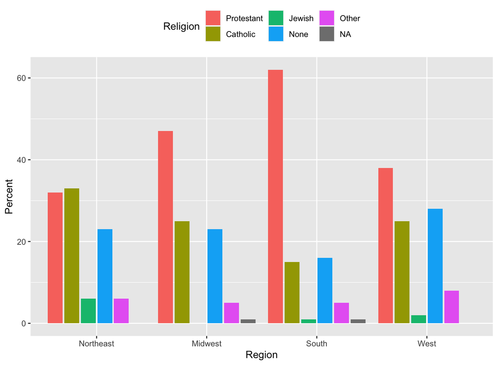

## Use pipes to summarize data

```r
p <- ggplot(rel_by_region, aes(x = religion, y = pct, fill = religion))

p + geom_col(position = "dodge2") +
    labs(x = NULL, y = "Percent", fill = "Religion") +
    guides(fill = "none") +
    coord_flip() +
    facet_grid(~ bigregion)
```

- The `coord_flip()` function switches the x and y axes after the plot is made.

## Use pipes to summarize data

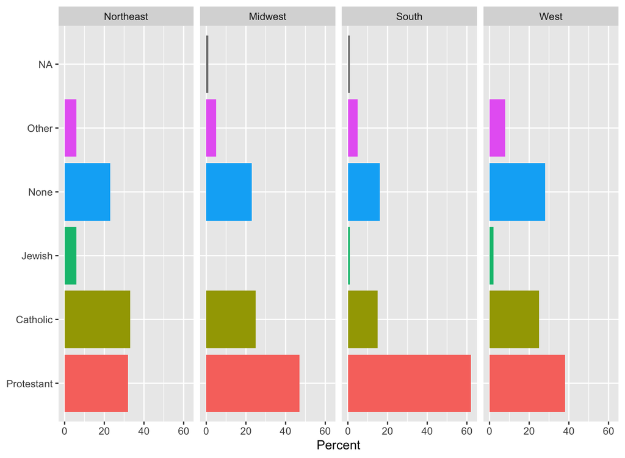

## The `organdata` data

- The `socviz` package includes the `organdata` data frame.
  - `organdata` contains a little more than a decade’s worth of information on the donation of organs for transplants in seventeen OECD countries.

```r
?organdata
glimpse(organdata)
skim(organdata)
view(organdata)
```

## Continuous variables by group or category

```r
p <- ggplot(data = organdata,
            mapping = aes(x = year, y = donors))
p + geom_point()
```

- Would it be informative?

## Continuous variables by group or category

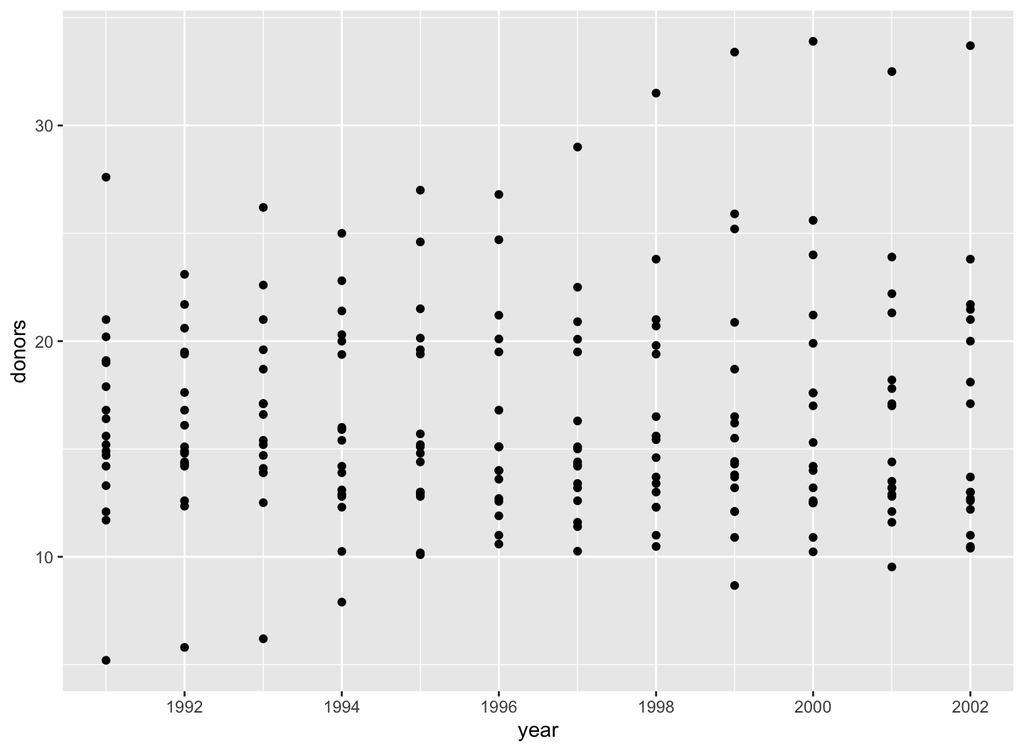

## Continuous variables by group or category

```r
p <- ggplot(data = organdata,
            mapping = aes(x = year, y = donors))
p + geom_line(aes(group = country)) + facet_wrap(~ country) +
  theme(axis.text.x = element_text(angle = 45))
```

- We could use `geom_line()` to plot each country’s time series.
- We can also facet the figure by country.

## Continuous variables by group or category

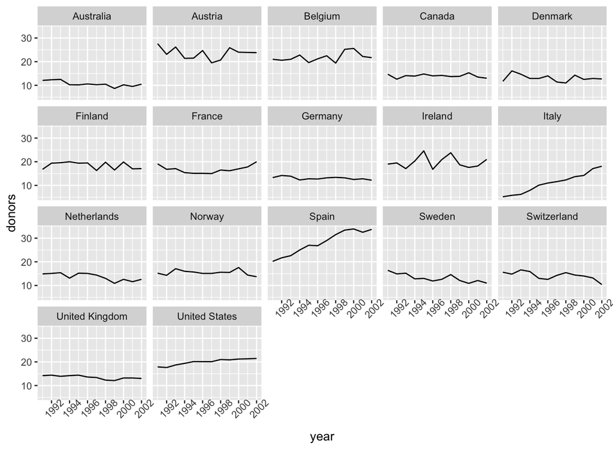

## Continuous variables by group or category

```r
p <- ggplot(data = organdata,
            mapping = aes(x = country, y = donors))
p + geom_boxplot() + coord_flip()
```

- We can use `geom_boxplot()` to get a picture of variation by year across countries.

## Continuous variables by group or category

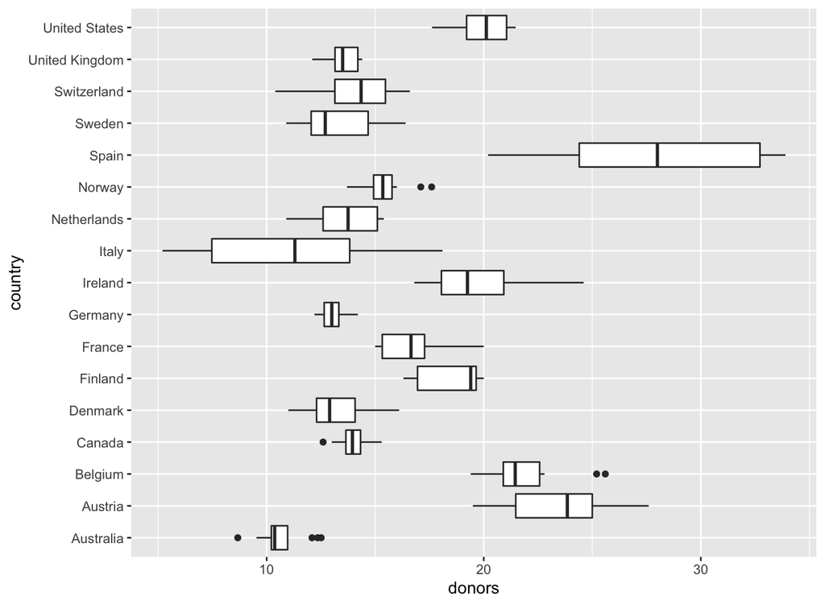

## Continuous variables by group or category

```r
p <- ggplot(data = organdata,
            mapping = aes(x = reorder(country, donors, na.rm=TRUE),
                          y = donors))
p + geom_boxplot() +
    labs(x=NULL) +
    coord_flip()
```

- We generally want our plots to present data in some meaningful order.
- The `reorder()` function will do this for us.
  - `reorder(country, donors)`: Reorder `country` by `donors`.

## Continuous variables by group or category

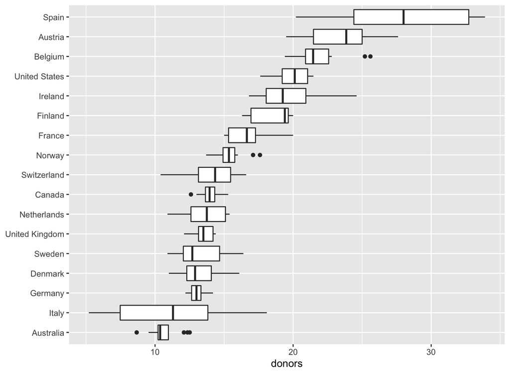

## Continuous variables by group or category

```r
p <- ggplot(data = organdata,
            mapping = aes(x = reorder(country, donors, na.rm=TRUE),
                          y = donors, fill = world))
p + geom_boxplot() + labs(x=NULL) +
    coord_flip() + theme(legend.position = "top")
```

- Boxplots can also take `color` and `fill` aesthetic mappings like other geoms.
- The plots can be quite compact and fit a relatively large number of cases in by row.

## Continuous variables by group or category

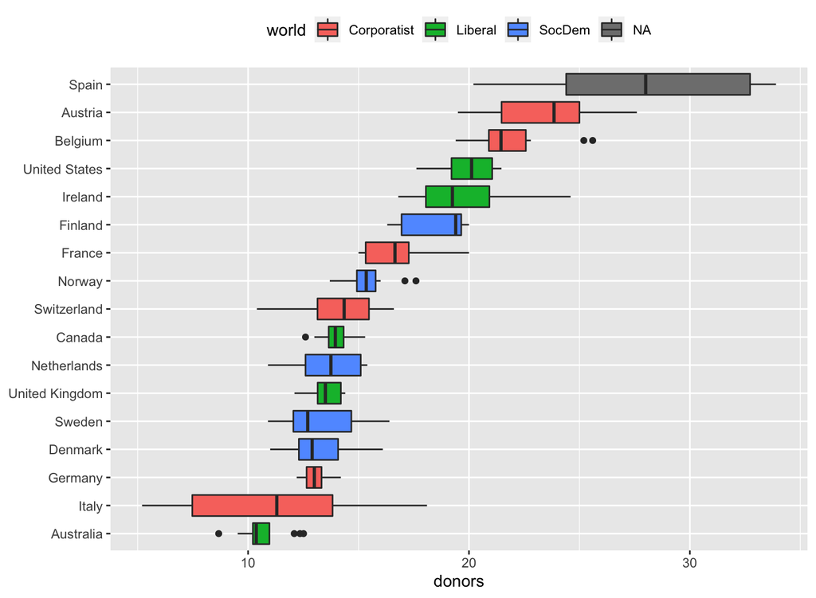

## Continuous variables by group or category

```r
p <- ggplot(data = organdata,
            mapping = aes(x = reorder(country, donors, na.rm=TRUE),
                          y = donors, color = world))
p + geom_point(alpha = .5) + labs(x=NULL) +
    coord_flip() + theme(legend.position = "top")
```

- When we use `geom_point()` like this, there is some overplotting of observations.

## Continuous variables by group or category

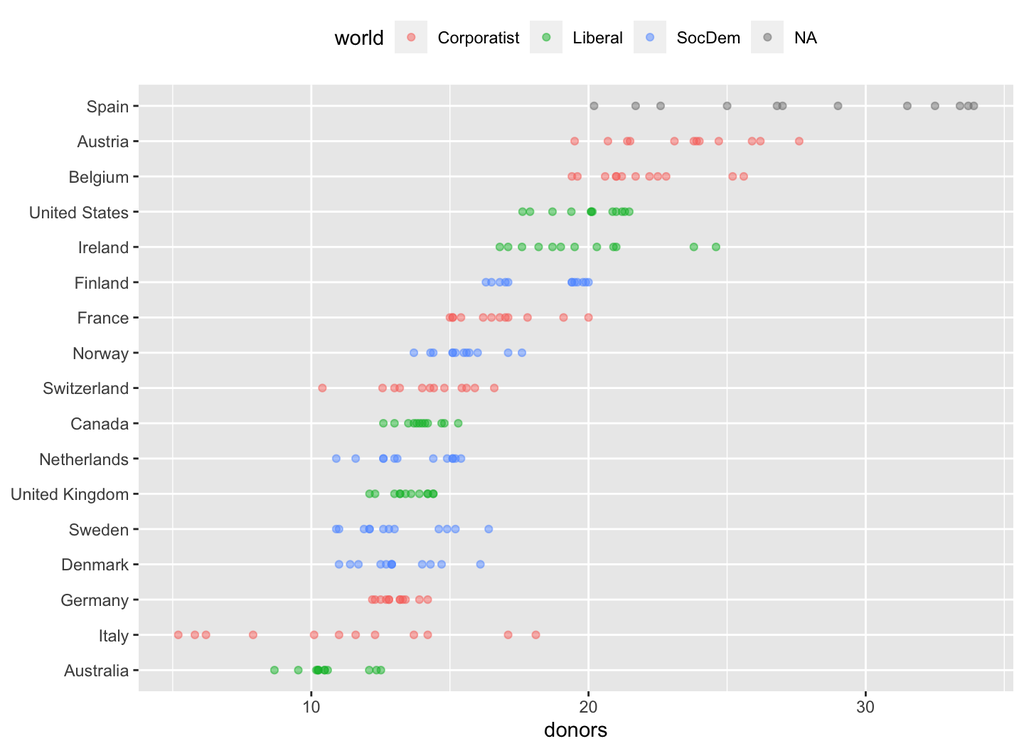

## Continuous variables by group or category

```r
p <- ggplot(data = organdata,
            mapping = aes(x = reorder(country, donors, na.rm=TRUE),
                          y = donors, color = world))
p + geom_jitter(position = position_jitter(width=0.15)) +
    labs(x=NULL) + coord_flip() + theme(legend.position = "top")
```

- `geom_jitter()` can be useful to perturb the data just a little bit in order to get a better sense of how many observations there are at different values.

## Continuous variables by group or category

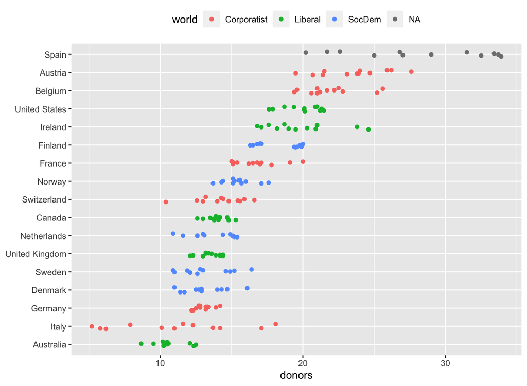

## Continuous variables by group or category

```r
p <- ggplot(data = organdata,
            mapping = aes(x = reorder(country, donors, na.rm=TRUE),
                          y = donors, color = world))
p + geom_jitter(position = position_jitter(width=0.15)) +
    labs(x=NULL) + coord_flip() + theme(legend.position = "top")
```

- We can control it using `height` and `width` arguments to a `position_jitter()` function within the geom.

## Continuous variables by group or category

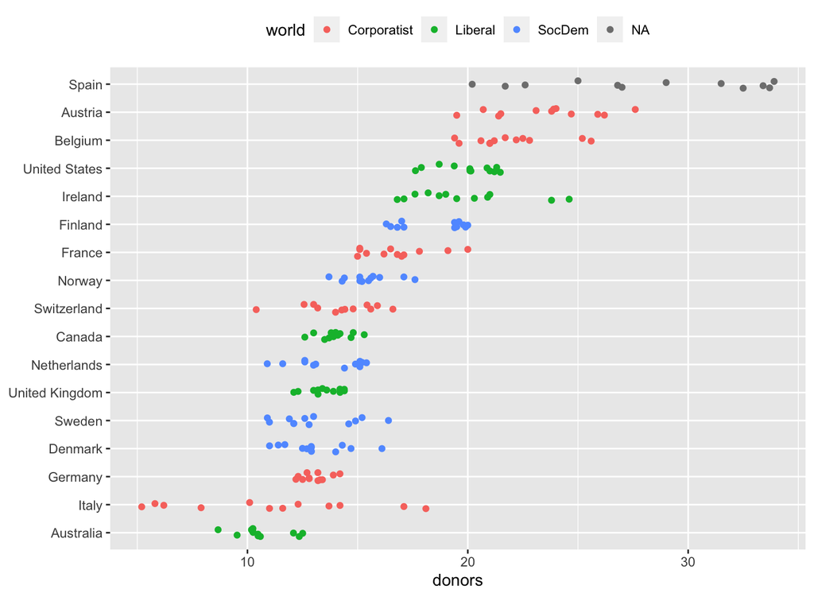

## Continuous variables by group or category

- When we want to summarize a categorical variable that just has one point per category, we should use this approach as well.

## Continuous variables by group or category

```r
by_country <- organdata %>% group_by(consent_law, country) %>%
    summarize(donors_mean= mean(donors, na.rm = TRUE),
              donors_sd = sd(donors, na.rm = TRUE),
              gdp_mean = mean(gdp, na.rm = TRUE),
              health_mean = mean(health, na.rm = TRUE),
              roads_mean = mean(roads, na.rm = TRUE),
              cerebvas_mean = mean(cerebvas, na.rm = TRUE))

by_country
```

```
## # A tibble: 17 × 8
## # Groups:   consent_law [2]
##    consent_law country     donors_mean donors_sd gdp_mean health_mean roads_mean
##    <chr>       <chr>             <dbl>     <dbl>    <dbl>       <dbl>      <dbl>
##  1 Informed    Australia          10.6     1.14    22179.       1958.      105.
##  2 Informed    Canada             14.0     0.751   23711.       2272.      109.
##  3 Informed    Denmark            13.1     1.47    23722.       2054.      102.
##  4 Informed    Germany            13.0     0.611   22163.       2349.      113.
##  5 Informed    Ireland            19.8     2.48    20824.       1480.      118.
##  6 Informed    Netherlands        13.7     1.55    23013.       1993.       76.1
##  7 Informed    United Kin…        13.5     0.775   21359.       1561.       67.9
##  8 Informed    United Sta…        20.0     1.33    29212.       3988.      155.
##  9 Presumed    Austria            23.5     2.42    23876.       1875.      150.
## 10 Presumed    Belgium            21.9     1.94    22500.       1958.      155.
## 11 Presumed    Finland            18.4     1.53    21019.       1615.       93.6
## 12 Presumed    France             16.8     1.60    22603.       2160.      156.
## 13 Presumed    Italy              11.1     4.28    21554.       1757       122.
## 14 Presumed    Norway             15.4     1.11    26448.       2217.       70.0
## 15 Presumed    Spain              28.1     4.96    16933        1289.      161.
## 16 Presumed    Sweden             13.1     1.75    22415.       1951.       72.3
## 17 Presumed    Switzerland        14.2     1.71    27233        2776.       96.4
## # … with 1 more variable: cerebvas_mean <dbl>
```

## Continuous variables by group or category

- What we would like to do is apply the `mean()` and `sd()` functions to every numerical variable in `organdata`, but only the numerical ones.
- `summarize_if()` examines each column in our data and applies a test to it.
  - `summarize_if()` only summarizes if the test is passed, that is, if it returns a value of `TRUE`.

## Continuous variables by group or category

```r
by_country <- organdata %>% group_by(consent_law, country) %>%
    summarize_if(is.numeric, funs(mean, sd), na.rm = TRUE) %>%
    ungroup()

by_country
```

```
## # A tibble: 17 × 28
##    consent_law country  donors_mean pop_mean pop_dens_mean gdp_mean gdp_lag_mean
##    <chr>       <chr>          <dbl>    <dbl>         <dbl>    <dbl>        <dbl>
##  1 Informed    Austral…        10.6   18318.         0.237   22179.       21779.
##  2 Informed    Canada          14.0   29608.         0.297   23711.       23353.
##  3 Informed    Denmark         13.1    5257.        12.2     23722.       23275
##  4 Informed    Germany         13.0   80255.        22.5     22163.       21938.
##  5 Informed    Ireland         19.8    3674.         5.23    20824.       20154.
##  6 Informed    Netherl…        13.7   15548.        37.4     23013.       22554.
##  7 Informed    United …        13.5   58187.        24.0     21359.       20962.
##  8 Informed    United …        20.0  269330.         2.80    29212.       28699.
##  9 Presumed    Austria         23.5    7927.         9.45    23876.       23415.
## 10 Presumed    Belgium         21.9   10153.        30.7     22500.       22096.
## 11 Presumed    Finland         18.4    5112.         1.51    21019.       20763
## 12 Presumed    France          16.8   58056.        10.5     22603.       22211.
## 13 Presumed    Italy           11.1   57360.        19.0     21554.       21195.
## 14 Presumed    Norway          15.4    4386.         1.35    26448.       25769.
## 15 Presumed    Spain           28.1   39666.         7.84    16933        16584.
## 16 Presumed    Sweden          13.1    8789.         1.95    22415.       22094
## 17 Presumed    Switzer…        14.2    7037.        17.0     27233        26931.
## # … with 21 more variables: health_mean <dbl>, health_lag_mean <dbl>,
## #   pubhealth_mean <dbl>, roads_mean <dbl>, cerebvas_mean <dbl>,
## #   assault_mean <dbl>, external_mean <dbl>, txp_pop_mean <dbl>,
## #   donors_sd <dbl>, pop_sd <dbl>, pop_dens_sd <dbl>, gdp_sd <dbl>,
## #   gdp_lag_sd <dbl>, health_sd <dbl>, health_lag_sd <dbl>, pubhealth_sd <dbl>,
## #   roads_sd <dbl>, cerebvas_sd <dbl>, assault_sd <dbl>, external_sd <dbl>,
## #   txp_pop_sd <dbl>
```

## Cleveland dotplot

```r
p <- ggplot(data = by_country,
            mapping = aes(x = donors_mean, y = reorder(country, donors_mean),
                          color = consent_law))
p + geom_point(size=3) +
    labs(x = "Donor Procurement Rate",
         y = "", color = "Consent Law") +
    theme(legend.position="top")
```

- **Cleveland dotplot** is a simple and extremely effective method of presenting data that is usually better than either a bar chart or a table.

## Cleveland dotplot

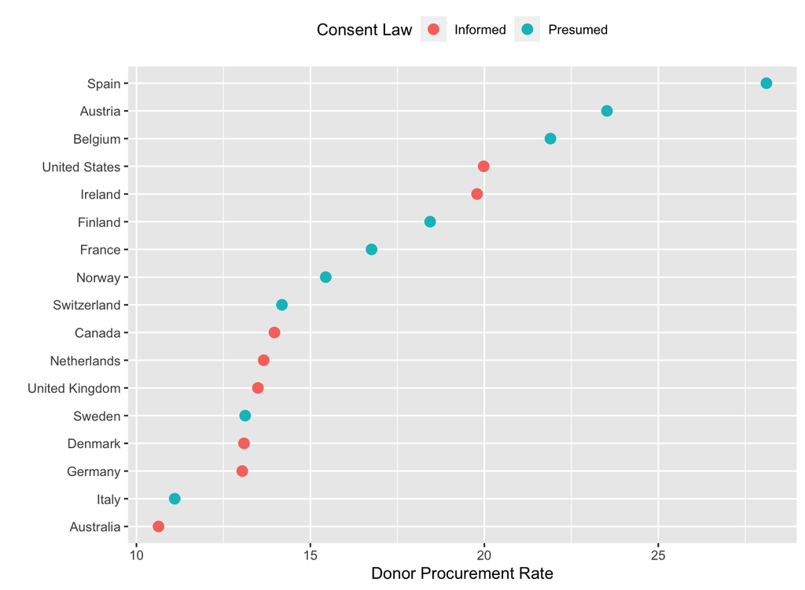

## Cleveland dotplot

```r
p <- ggplot(data = by_country,
            mapping = aes(x = donors_mean,
                          y = reorder(country, donors_mean)))

p + geom_point(size=3) +
    facet_wrap(~ consent_law, scales = "free_y", ncol = 1) +
    labs(x= "Donor Procurement Rate",
         y= "")
```

- We could use a facet instead of coloring the points.
- In the `facet_wrap()` here, …
  - `scales = "free_y"` allows the y-axes scale to be free, which removes countries that do not dots in the panel.
  - `ncol=1` makes it easy to compare.

## Cleveland dotplot

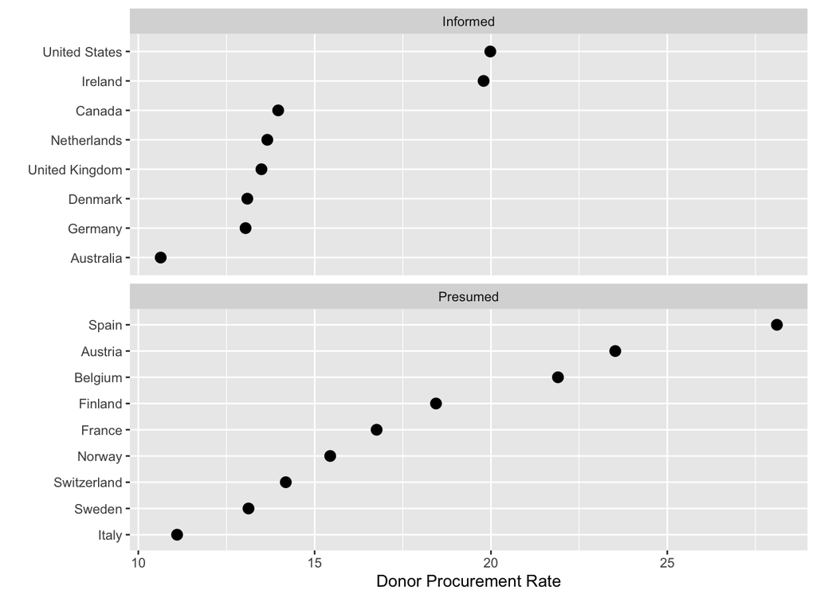

## Cleveland dotplot

```r
p <- ggplot(data = by_country, mapping = aes(x = reorder(country,
              donors_mean), y = donors_mean))

p + geom_pointrange(mapping = aes(ymin = donors_mean - donors_sd,
       ymax = donors_mean + donors_sd)) +
     labs(x= "", y= "Donor Procurement Rate") + coord_flip()
```

- The Cleveland-style dotplot can be extended to cases where we want to include some information about variance or error in the plot.
- Using `geom_pointrange()`, we can tell ggplot to show us a point estimate and a range around it.

## Cleveland dotplot

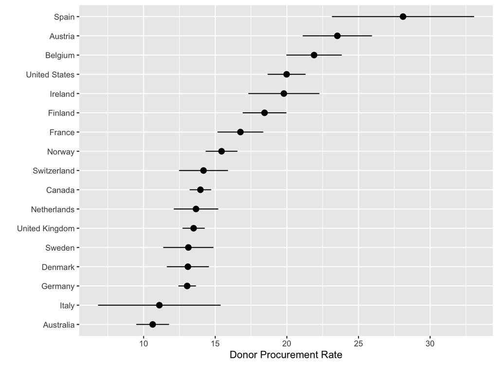

## Plot text directly

```r
p <- ggplot(data = by_country,
            mapping = aes(x = roads_mean, y = donors_mean))
p + geom_point() + geom_text(mapping = aes(label = country))
```

- It can sometimes be useful to plot the labels along with the points in a scatterplot, or just plot informative labels directly.
  - We can do this with `geom_text()`.

## Plot text directly

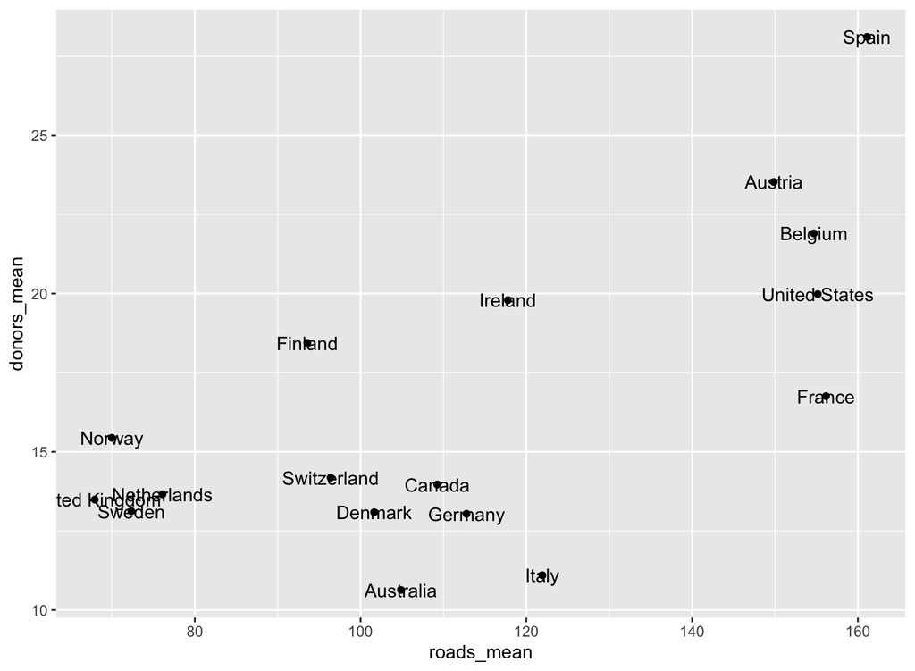

## Plot text directly

```r
p <- ggplot(data = by_country,
            mapping = aes(x = roads_mean, y = donors_mean))

p + geom_point() + geom_text(mapping = aes(label = country), hjust = 0)
```

- We can left- or right-justify the labels using the `hjust` argument to `geom_text()`.
  - Setting `hjust=0` will left justify the label, and `hjust=1` will right justify it.
  - Trying different values to `hjust` is not a robust approach.

## Plot text directly

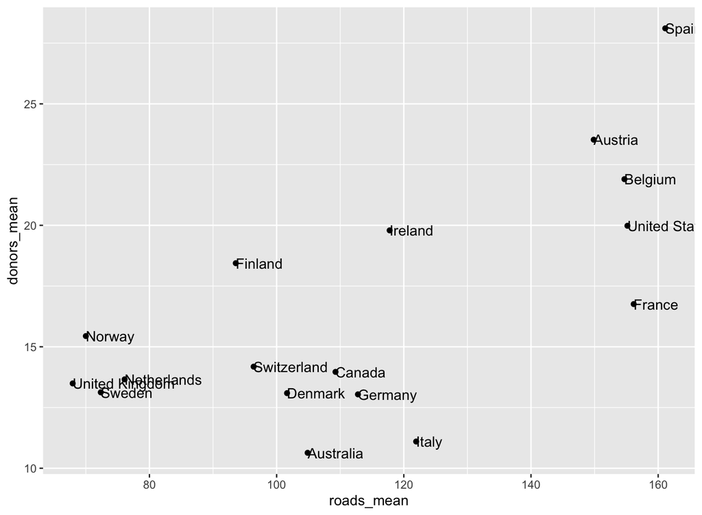

## Historical U.S. presidential election data

- The `socviz` package includes the `elections_historic` data frame.
  - `elections_historic` provides historical U.S. presidential election data.

```r
?elections_historic
glimpse(elections_historic)
skim(elections_historic)
view(elections_historic)
```

## Plot text directly

```r
p_title <- "Presidential Elections: Popular & Electoral College Margins"
p_subtitle <- "1824-2016"
p_caption <- "Data for 2016 are provisional."
x_label <- "Winner's share of Popular Vote"
y_label <- "Winner's share of Electoral College Votes"
p <- ggplot(elections_historic, aes(x = popular_pct, y = ec_pct, label = winner_label))
p + geom_hline(yintercept = 0.5, size = 1.4, color = "gray80") +
    geom_vline(xintercept = 0.5, size = 1.4, color = "gray80") +
    geom_point() + geom_text_repel() +
    scale_x_continuous(labels = scales::percent) +
    scale_y_continuous(labels = scales::percent) +
    labs(x = x_label, y = y_label, title = p_title, subtitle = p_subtitle,
         caption = p_caption)
```

- `geom_hline()` and `geom_vline()` to make the lines.
- `geom_text_repel()` makes sure the labels do not overlap with each other, or obscure other points.

## Plot text directly

[figure not shown]